# Data Analytics Portfolio

Michael Molloy

2019-08-02

# 1 Home

# 2 Data Analysis

## 2.1 HIPAA Breaches

### 2.1.1 Breaches over time

The Office for Civil Rights publishes a dataset of reported breaches going back as far as 2009. If we graph the number of breaches reported each month over the past 9 years the trend is clear. We can also see a few months with a high number of “Individuals Affected” around 2015 (represented by the size of the dot). The most notable being the Anthem breach reported in February 2015 which affected 78,800,000 people.

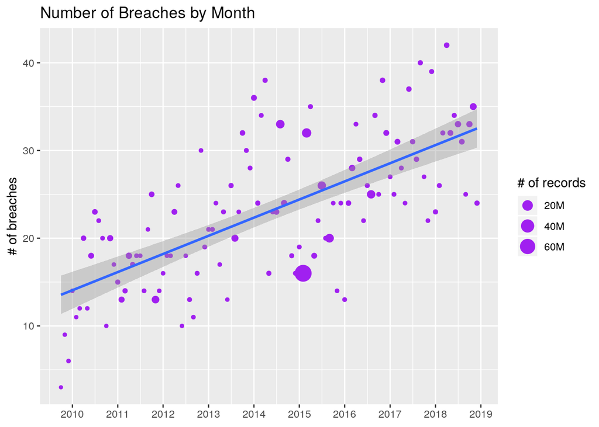

### 2.1.2 Types of Breaches

The most common types of breaches are hacking, theft, and unauthorized access. Breach repors can contain multiple breach types, so some parsing had to be done in order to create a meaningful chart on this field. The graph below shows the number of reported breaches per month distinguished by their breach type using color. The size of the dot, similar to our previous chart, shows the relative sum of the records (i.e. individuals affected) for the breaches in the month.

A few things stand out in this chart. Most notably that the reporting of theft has been declining sharply and the reports of unauthorized access and hacking have been increasing. My hypothesis on why the reports of theft have dropped is that the prevalence of encrypted storage has increased. This is a purely anecdotal observation from my experience in IT Risk over the past 10 years, but it makes sense. If a laptop is stolen but its hard drive is encrypted, OCR does not consider the data on that hard drive accessible to an unauthorized user and therefore would not constitute a reportable breach.

My other observation is that the biggest breaches (i.e. ones that affect the most individuals) are related to hacking. When you combine that with the increase in hacking incidents it paints a dire picture for individual privacy.

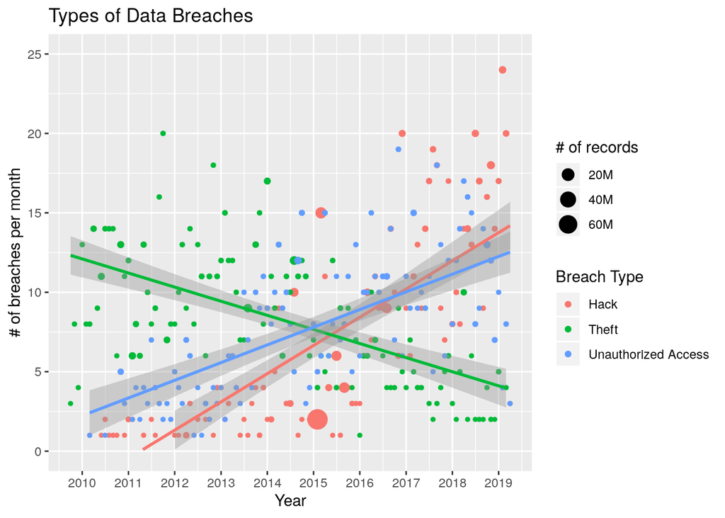

### 2.1.3 Breach Map

#### 2.1.3.1 Total Breaches by State

The map below shows the total number of breaches by state. At first glance, it appears as though covered entities in California, Texas, and Florida have much higher occurrences of data breaches than covered entities in other states. However, this map looks a lot like a map of state populations from the 2015 census (see the next tab).

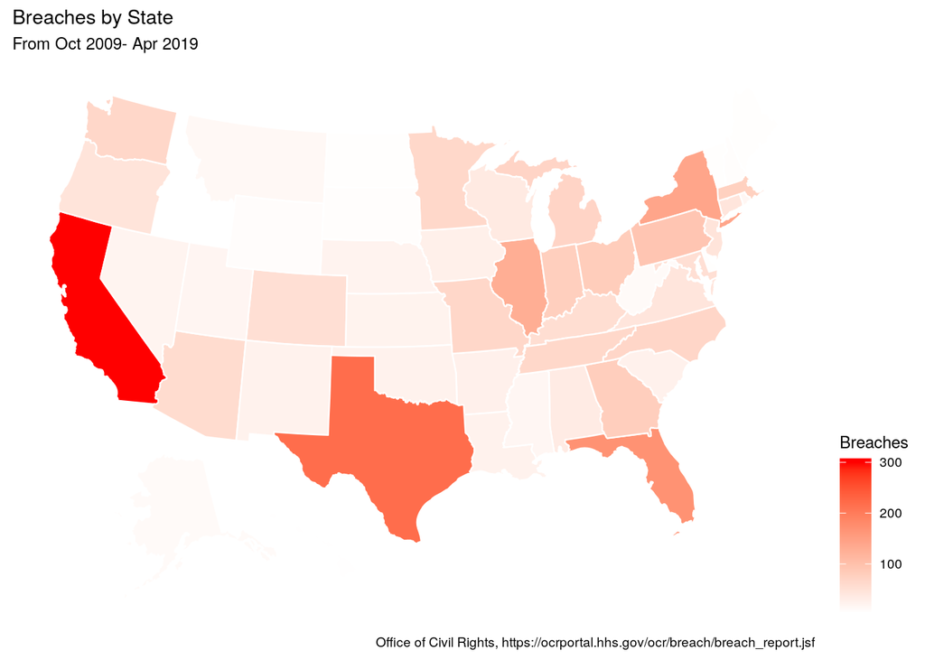

#### 2.1.3.2 Population Map

There appears to be a correlation between the number of breaches in each state and the population. It might be worth exploring this further. I’d want to test the hypothesis that a higher population means more covered entities (i.e. hospitals) which are available to be breached in a given state. The next tab shows a more normal distribution of breaches across the US.

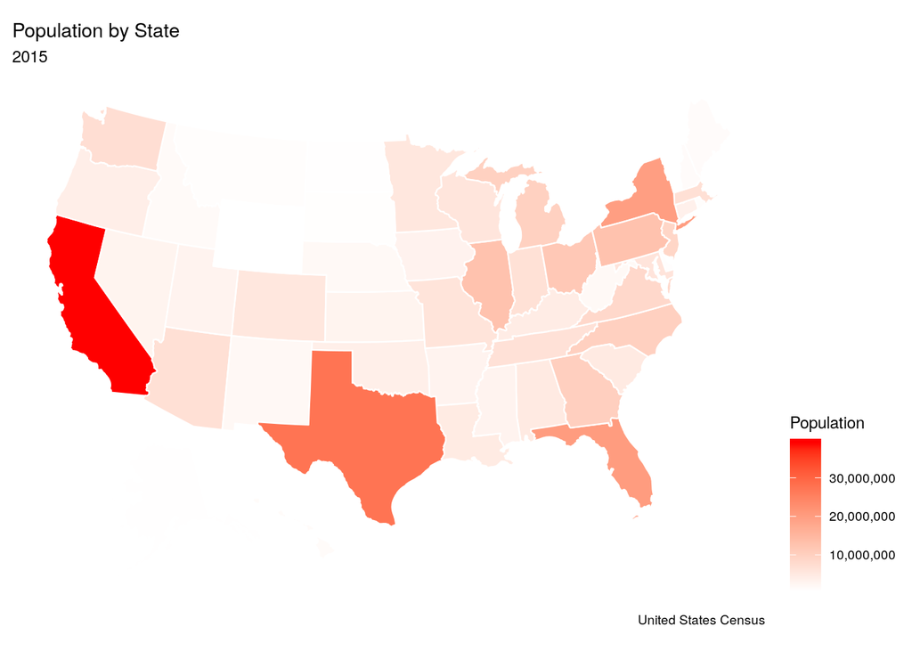

#### 2.1.3.3 Breaches by Population

I normalized the breaches by dividing the number of breaches by the total state population. I expect this represents a more accurate picture, but statistical analysis would need to be done to determine whether a particular state is more likely to have a breach than others.

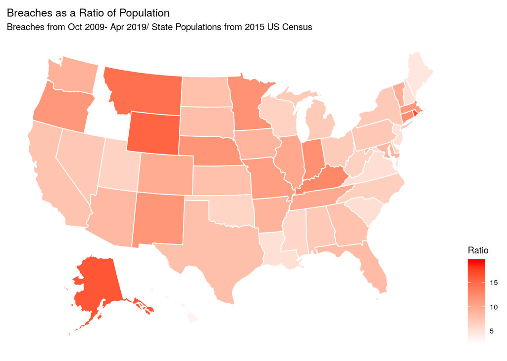

### 2.1.4 Covered Entities

#### 2.1.4.1 Most Breached Entities

I also wanted to see which covered entities incurred the most breaches. I found quality issues with the covered entity name column. I used a clustering algorithm to automatically group like names, then created a “mapping table” (see other tab) of rules based on those clusters. After running the mapping table logic, I was able to count all the breaches by entity and get a more accurate picture of the covered entities with the most reported breaches.

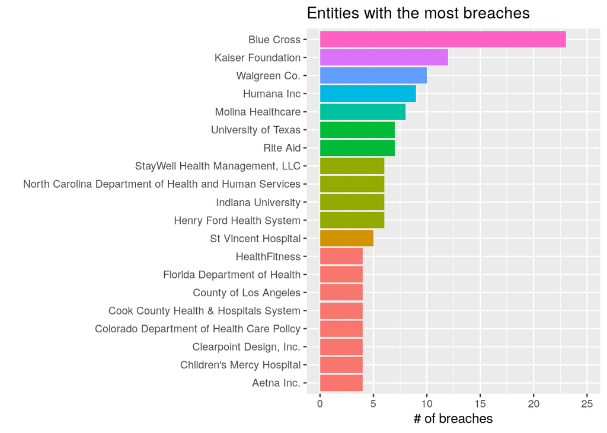

#### 2.1.4.2 Mapping Table

| from | to |
| --- | --- |
| .*Rite Aid.* | Rite Aid |
| .*Blue Cross.* | Blue Cross |
| .*Texas Health Human.* | Texas Health Human Services |
| privacy manager breach |  |
| .*Kaiser Foundation.* | Kaiser Foundation |
| .*University of Wisconsin.* | University of Wisconsin |
| .*University of Illinois.* | University of Illinois |
| .*United Health.* | United Health |
| .*Triples Salud.* | Triples Salud |
| .*Molina.* | Molina Healthcare |
| .*University of Kentucky.* | University of Kentucky |
| .*University of Texas.* | University of Texas |
| .*South Carolina Department.* | South Carolina Department of Health |
| .*North Carolina Department.* | North Carolina Department of Health and Human Services |
| .*Vincent Hospital.* | St Vincent Hospital |
| .*Indiana University.* | Indiana University |
| .*Florida Department.* | Florida Department of Health |
| .*Humana.* | Humana Inc |
| .*Kern Medical.* | Kern Medical Center |
| .*Colorado Department.* | Colorado Department of Health Care Policy |

### 2.1.5 Conclusion

Cyber criminals are attacking organizations of all sizes and industry verticals as IT and Security departments struggle to keep up with the latest threats. The Healthcare industry has seen an increase in the number of breaches over the past few years, especially those related to hacking. Understanding the threat landscape is an important part of increasing the privacy protections over patient data and identifying solutions that reduce breaches.

# 3 Code Examples

## 3.1 Clustering

Clustering allows for more automated pattern recognition within datasets. I found it helpful in identifying instances where company names were entered with slight variations (i.e. “Clearview”, “ClearView Inc.”, “Clearview Group”), making grouping and counting impossible. We can use clustering to identify the similarities and write data wrangling scripts to tidy up the data for further analysis.

### 3.1.1 Illustrative Example

The example below uses board games ratings data. Clustering can be used to identify games with similar names.

```r
# Load packages
library(tidyverse)
library(dplyr)
library(ggplot2)
library(kableExtra)
library(stringdist)
library(reshape2)
library(stringr)
library(tm)
library(wordcloud2)

# read data
data <- readr::read_csv("https://raw.githubusercontent.com/rfordatascience/tidytuesday/master/data/2019/2019-03-12/board_games.csv")

# select the field in the dataset with which you want to perform clustering
Field <- head(data$name, 1000)

# create the stringdistmatrix using the Jaro–Winkler distance algorithm
UniqueField <- unique(as.character(Field))

DistanceField <- stringdistmatrix(UniqueField,UniqueField,method = "jw") # you can experiment with changing the method to get better results

rownames(DistanceField) <- UniqueField

# loop the clustering algorithm until it reaches the desired average number of records. the thought being that if we have a dataset with records we expect to be mostly unique than the average records in a cluster will be low.  This loop will determine the right number of clusters for your dataset.

  # set starting number of clusters
  i <- 1

  # set a starting avg_cluster (should be greater than x)
  avg_cluster <- 10

  # this one is important. how many records do you expect to be similar?
  x <- 2

  # define variable for use in clustering algorithm
  hc <- hclust(as.dist(DistanceField))

  # begin the loop
  while (avg_cluster > x) {
     dfClust <- data.frame(UniqueField, cutree(hc, k=i))
     names(dfClust) <- c('UniqueField','cluster')
     avg_cluster <- mean(table(dfClust$cluster))
     i = i+1
     }

# compile the cluster data into a data.frame
t <- table(dfClust$cluster)
t <- cbind(t,t / length(dfClust$cluster))
t <- t[order(t[,2], decreasing=TRUE),]
p <- data.frame(factorName=rownames(t), binCount=t[,1], percentFound=t[,2])


dfClust <- merge(x=dfClust, y=p, by.x = 'cluster', by.y='factorName', all.x=T)

dfClust <- dfClust[rev(order(dfClust$binCount,dfClust$cluster)),] # sort by the size of the cluster bin then the cluster ID

names(dfClust) <-  c('cluster','UniqueField','binCount')
```

The relationship between the number of clusters and the total number of records is interesting. In theory, if a dataset has no discernable patterns with which to cluster on, then the number of clusters would be equal to the number of records. In other words, each record would be its own “cluster”.

```r
# How many clusters did we end up with?
print(paste('Number of clusters:', i))
```

```
## [1] "Number of clusters: 500"
```

```r
# How many records in the dataset?
print(paste('Number of records:',NROW(data)))
```

```
## [1] "Number of records: 10532"
```

Now we can take a look at the top results to start identifying the “real” patterns and further refining our data.

```r
# print cluster results
kable(dfClust[order(dfClust[1:200,3], dfClust[1:200,2], decreasing = T),1:2]) %>%
  kable_styling(bootstrap_options = c("striped","hover", "condensed","responsive"),fixed_thead = T) %>%
  column_spec(1, bold = T, border_right = T) %>%
  column_spec(2, width = "5m")
```

|  | cluster | UniqueField |
| --- | --- | --- |
| 70 | 24 | Battlemist |
| 74 | 24 | Battle of the Bulge |
| 69 | 24 | Battle of the Bands |
| 72 | 24 | Battle Masters |
| 71 | 24 | Battle Line |
| 76 | 24 | Battle Cry |
| 75 | 24 | Battle Cattle |
| 73 | 24 | Bali |
| 10 | 2 | Dragons of Glory |
| 14 | 2 | Dragonmaster |
| 13 | 2 | Dragonlance |
| 11 | 2 | Dragonhunt |
| 9 | 2 | Dragon’s Gold |
| 12 | 2 | Dragon Strike |
| 8 | 2 | Dragon Masters |
| 5 | 1 | Die Weinhändler |
| 4 | 1 | Die Seidenstraße |
| 6 | 1 | Die Osterinsel |
| 3 | 1 | Die Mauer |
| 2 | 1 | Die Magier |
| 1 | 1 | Die Macher |
| 7 | 1 | Die Hanse |
| 604 | 268 | 1856 |
| 608 | 268 | 1853 |
| 606 | 268 | 1851 |
| 605 | 268 | 1835 |
| 607 | 268 | 1826 |
| 603 | 268 | 1825 Unit 1 |
| 480 | 211 | Wizards |
| 484 | 211 | Wizard’s Quest |

[output cut: 170 more lines]

## 3.2 Word Clouds

Word clouds are an interesting way to visualize the frequency of words in a dataset.

### 3.2.1 Packages

The “tm” package helps to clean up the data by removing special characters, punctuation, etc. The “wordcloud2” package is used to display the most common words visually in the form of a word cloud.

### 3.2.2 Illustrative Example

The example below contains a word cloud for the description of UFO sightings collected by THE NATIONAL UFO REPORTING CENTER.

```r
# Load packages
library(tidyverse)
library(dplyr)
library(ggplot2)
library(kableExtra)
library(stringdist)
library(reshape2)
library(stringr)

# read data
data <- readr::read_csv("https://raw.githubusercontent.com/rfordatascience/tidytuesday/master/data/2019/2019-06-25/ufo_sightings.csv")

# select the field in the dataset with which you want to create the word cloud.
Field <- head(data$description, 1000) # for illustrative purpose only the first 1000 rows are used.


# the "tm" package cleans up the data in the field be seperating all of the words and normalizing them
toSpace <- content_transformer(function (x , pattern ) gsub(pattern, " ", x))
Field2 <- as.character(Field)
Field2 <- Corpus(VectorSource(Field2))
Field2 <- tm_map(Field2, toSpace, "/")
Field2 <- tm_map(Field2, toSpace, "@")
Field2 <- tm_map(Field2, toSpace, "\\|")
Field2 <- tm_map(Field2, content_transformer(tolower))
Field2 <- tm_map(Field2, removeNumbers)
Field2 <- tm_map(Field2, removePunctuation)
Field2 <- tm_map(Field2, stripWhitespace)
Field2 <- tm_map(Field2, removeWords, stopwords("english"))

# this section of code takes all of the individual words and determines their frequency
dtm <- TermDocumentMatrix(Field2)
m <- as.matrix(dtm)
v <- sort(rowSums(m),decreasing=TRUE)
d <- data.frame(word = names(v),freq=v)

# this creates the word cloud image
wordcloud2(d[1:50,1:2])
```

[interactive chart not shown]